# [Coursera](https://www.coursera.org) - An Online Learning Platform

[Plotting with ggplot2](https://www.coursera.org/learn/r-data-visualization)

[®γσ, ξηg Lιαη Ημ](https://englianhu.github.io/) 🇪🇺® 新

2021-12-08

**Theme Song**

[interactive chart not shown]

# 1 Setting

## 1.1 SCSS Setup

```r
# install.packages("remotes")
library('BBmisc', 'rmsfuns')
#remotes::install_github("rstudio/sass")
lib('sass')
```

```
## sass
## TRUE
```

```
/* https://stackoverflow.com/a/66029010/3806250 */
h1 { color: #002C54; }
h2 { color: #2F496E; }
h3 { color: #375E97; }
h4 { color: #556DAC; }
h5 { color: #92AAC7; }

/* ----------------------------------------------------------------- */
/* https://gist.github.com/himynameisdave/c7a7ed14500d29e58149#file-broken-gradient-animation-less */
.hover01 {
  /* color: #FFD64D; */
  background: linear-gradient(155deg, #EDAE01 0%, #FFEB94 100%);
  transition: all 0.45s;
  &:hover{
    background: linear-gradient(155deg, #EDAE01 20%, #FFEB94 80%);
    }
  }

.hover02 {
  color: #FFD64D;
  background: linear-gradient(155deg, #002C54 0%, #4CB5F5 100%);
  transition: all 0.45s;
  &:hover{
    background: linear-gradient(155deg, #002C54 20%, #4CB5F5 80%);
    }
  }

.hover03 {
  color: #FFD64D;
  background: linear-gradient(155deg, #A10115 0%, #FF3C5C 100%);
  transition: all 0.45s;
  &:hover{
    background: linear-gradient(155deg, #A10115 20%, #FF3C5C 80%);
    }
  }
```

```r
## https://stackoverflow.com/a/36846793/3806250
options(width = 999)
knitr::opts_chunk$set(class.source = 'hover01', class.output = 'hover02', class.error = 'hover03')
```

## 1.2 Setup

```r
suppressPackageStartupMessages(library('BBmisc'))

pkgs <- c('knitr', 'kableExtra', 'devtools', 'lubridate', 'data.table', 'tidyquant', 'stringr', 'magrittr', 'tidyverse', 'plyr', 'dplyr', 'broom', 'highcharter', 'formattable', 'DT', 'httr', 'openxlsx')
suppressAll(lib(pkgs))

#funs <- c('')
#l_ply(funs, function(x) source(paste0('./function/', x)))

Sys.setenv(TZ='Asia/Tokyo')
options(warn=-1)
rm(pkgs)
```

# 2 Introduction

## 2.1 About this Course

Kindly refer to manual [Mastering Software Development in R (web-base)](https://bookdown.org/rdpeng/RProgDA/). (or [Mastering Software Development in R.pdf](https://github.com/englianhu/Coursera-Mastering-Software-Development-in-R/blob/master/reference/Mastering%20Software%20Development%20in%20R.pdf))

## 2.2 Syllabus

- Week 1 : Welcome to Building Data Visualization Tools
  - Welcome
  - Video：Welcome to Building Data Visualization Tools
  - Reading：Textbook Mastering Software Development in R
  - Reading：syllabus
  - Basic plotting with ggplot2
    - Reading: Introduction
    - Reading: Initializing a ggplot Object
    - Reading: Plot Aesthetics
    - Reading: Creating a Basic ggplot plot
    - Reading: Geoms
    - Reading: Using Multiple geoms
    - Reading: Constant aesthetics
    - Reading: Example plots
    - Reading: Extentions of ggplot2
  - Customizing ggplot2 Plots
    - Reading: Introduction
    - Reading: Guideline for Good Plots
    - Reading: Scales and Color
    - Reading: To Find Out More
  - ggplot Basic
    - Quiz: Plotting with ggplot2
- Week 2 : Mapping and interactive plots
  - Mapping
    - Reading: Introduction
    - Reading: ReadingBasics of Mapping
    - Reading: Readingggmap, Google Maps API
    - Reading: ReadingMapping US counties and states
    - Reading: ReadingMore advanced mapping– Spatial objects
    - Reading: ReadingWhere to find more on mapping with R
  - htmlWidgets
    - Reading: Overview of htmlWidgets
    - Reading: plotly Package
    - Reading: Creating Your Own Widget
  - Mapping Quiz
    - Mapping and interactive plots
- Week 3 : The grid Package
  - The grid package
    - Reading: Introduction
    - Reading: Overview of grid graphics
    - Reading: Grobs
    - Reading: Viewports
    - Reading: Grid Graphics Coordinate Systems
    - Reading: The gridExtra package
    - Reading: Where to Find More About grid Graphics
  - Grid Package quiz
    - Quiz: Basics of grid graphics
- Week 4 : Building New Graphical Elements
  - Building a New Theme
    - Reading: Introduction
    - Reading: Why Build a New Theme?
    - Reading: Default Theme
    - Reading: Building a New Theme
    - Reading: Summary
  - Build New Graphical Elements
    - Build New Graphical Elements
    - Reading: Introduction
    - Reading: Building a Geom
    - Reading: Example: An Automatic Transparency Geom
    - Reading: Building a Stat
    - Reading: Example: Normal Confidence Intervals
    - Reading: Combining Geoms and Stats
    - Reading: Summary
  - Build a New Geom
    - Peer-graded Assignment: Build a New Geom
    - Review Your Peers: Build a New Geom

Kindly refer to [Mastering Software Development in R Specialization](https://www.coursera.org/specializations/r) to know the whole courses for the R specialization.

```r
# 1:  <- ''
# 2:  <- ''
# 3:  <- ''
```

## 2.3 Lesson

### 2.3.1 Week 1 : Welcome to Building Data Visualization Tools

#### 2.3.1.1 Welcome

#### 2.3.1.2 Video：Welcome to Building Data Visualization Tools

#### 2.3.1.3 Reading：Textbook Mastering Software Development in R

#### 2.3.1.4 Reading：syllabus

#### 2.3.1.5 Basic plotting with ggplot2

**Reading: Introduction**

**Reading: Initializing a ggplot Object**

**Reading: Plot Aesthetics**

**Reading: Creating a Basic ggplot plot**

**Reading: Geoms**

**Reading: Using Multiple geoms**

**Reading: Constant aesthetics**

**Reading: Example plots**

**Reading: Extentions of ggplot2**

#### 2.3.1.6 Customizing ggplot2 Plots

**Reading: Introduction**

**Reading: Guideline for Good Plots**

**Reading: Scales and Color**

**Reading: To Find Out More**

#### 2.3.1.7 ggplot Basic

**Quiz: Plotting with ggplot2**

### 2.3.2 Week 2 : Mapping and interactive plots

#### 2.3.2.1 Mapping

**Reading: Introduction**

**Reading: ReadingBasics of Mapping**

**Reading: Readingggmap, Google Maps API**

**Reading: ReadingMapping US counties and states**

**Reading: ReadingMore advanced mapping– Spatial objects**

**Reading: ReadingWhere to find more on mapping with R**

#### 2.3.2.2 htmlWidgets

**Reading: Overview of htmlWidgets**

**Reading: plotly Package**

**Reading: Creating Your Own Widget**

#### 2.3.2.3 Mapping Quiz

**Mapping and interactive plots**

### 2.3.3 Week 3 : The grid Package

#### 2.3.3.1 The grid package

**Reading: Introduction**

**Reading: Overview of grid graphics**

**Reading: Grobs**

**Reading: Viewports**

**Reading: Grid Graphics Coordinate Systems**

**Reading: The gridExtra package**

**Reading: Where to Find More About grid Graphics**

### 2.3.4 Grid Package quiz

**Quiz: Basics of grid graphics**

### 2.3.5 Week 4 : Building New Graphical Elements

## 2.4 Building a New Theme

**Reading: Introduction**

**Reading: Why Build a New Theme?**

**Reading: Default Theme**

**Reading: Building a New Theme**

**Reading: Summary**

## 2.5 Build New Graphical Elements

### 2.5.1 Build New Graphical Elements

**Reading: Introduction**

**Reading: Building a Geom**

**Reading: Example: An Automatic Transparency Geom**

**Reading: Building a Stat**

**Reading: Example: Normal Confidence Intervals**

**Reading: Combining Geoms and Stats**

**Reading: Summary**

# 3 Quiz

1. The function `ggplot()` requires that the value supplied to the ‘data’ argument be a
- character vector
- list
- **data frame**
- geom
2. You run the following code and get the error printed directly after the code:

```r
library(ggplot2)
library(faraway)
```

[output not shown]

```r
data(nepali)
head(nepali, 3)
```

```
## Error in head(nepali, 3): object 'nepali' not found
```

```r
## id sex wt ht mage lit died alive age
## 1 120011 1 12.8 91.2 35 0 2 5 41
## 2 120011 1 12.8 93.9 35 0 2 5 45
## 3 120011 1 13.1 95.2 35 0 2 5

ggplot(nepali, aes(x = ht, y = wt))
```

```
## Error in ggplot(nepali, aes(x = ht, y = wt)): object 'nepali' not found
```

```r
+ geom_point()
```

```
## Error: Cannot use `+.gg()` with a single argument. Did you accidentally put + on a new line?
```

```r
## Error in +geom_point(): invalid argument to unary operator
```

What happened?

Because you put the `+` at the start of the second line, instead of at the end of the first line, R thought the call was over and tried to run the first line by itself, and then tried to run the second line by itself, without an associated `ggplot` object.

- The `nepali` dataset lacks one or both of the two columns `(ht, wt)` that you - used in the `aes` statement of the call.
- You are trying to create a scatterplot for a categorical variable.
- You have not yet loaded the nepali data frame.

  ans: 3 ans: 2 ans: 1 ans: 4
3. You have a dataset of observations on study subjects which has height and weight for each subject measured at multiple time points. You want to create a `scatterplot` of height `(x-axis)` by weight `(y-axis)`. Since there are multiple measurements per subject, you would like to plot the measurements for each subject in a separate color. There is a column in the data called id that gives the unique id of each study subject; this column currently has the class “numeric”.

Which of the following choices is a good strategy for creating a plot where data points use color to identify the subject?

- Convert the id column of the data frame to a factor, so a discrete color palette will be used, then use ggplot to create a `scatterplot` and specify `color = id` as the sole argument in the `geom_point()` call.

Example code:

```r
df %>%
  mutate(id = factor(id)) %>%
  ggplot(aes(x = height, y = weight)) +
  geom_point(color = id)
```

```
## Error in mutate(., id = factor(id)): is.data.frame(.data) || is.list(.data) || is.environment(.data) is not TRUE
```

- **Leave the id column of the data frame as a numeric, so a continuous color palette will be used, and use `ggplot` to create a `scatterplot`, then use + to add the element `color(aes(id))`.**

Example code:

```r
df %>%
  ggplot(aes(x = height, y = weight)) +
  geom_point() +
  color(aes(id))
```

```
## Error:   You're passing a function as global data.
##   Have you misspelled the `data` argument in `ggplot()`
```

Example code:

```r
df %>%
  mutate(id = factor(id)) %>%
  ggplot(aes(x = height, y = weight, color = id)) +
  geom_point()
```

```
## Error in mutate(., id = factor(id)): is.data.frame(.data) || is.list(.data) || is.environment(.data) is not TRUE
```

- Convert the id column of the data frame to a factor, so a discrete color palette will be used, then use `ggplot2` to create a `scatterplot` and specify `color = id` in the `aes()` section of the `ggplot()` call.

Example code:

```r
df %>%
  mutate(id = factor(id)) %>%
  ggplot(aes(x = height, y = weight, color = id)) +
  geom_point()
```

```
## Error in mutate(., id = factor(id)): is.data.frame(.data) || is.list(.data) || is.environment(.data) is not TRUE
```

ans: 1

ans: 2

4. You want to save a figure from R as a pdf file named “MyFig.pdf”. Which of the following describes the proper steps to take?

First run all your code to create the figure, then run `pdf("MyFig.pdf")` to open a pdf device, then use `pdf.off()` to close the device.

Example code:

```r
ggplot(df, aes(x = x, y = y)) +
  geom_point()
```

```
## Error:   You're passing a function as global data.
##   Have you misspelled the `data` argument in `ggplot()`
```

```r
pdf("MyFig.pdf")
dev.off()
```

Wrap all your code to create the figure in a pdf statement.

Example code:

```r
ggplot(df, aes(x = x, y = y)) +
  geom_point()
```

```
## Error:   You're passing a function as global data.
##   Have you misspelled the `data` argument in `ggplot()`
```

```r
pdf("MyFig.pdf")
dev.off()
```

First run `dev.on("MyFig.pdf")` to open a pdf device, then run all your code to create the figure, then use `dev.off()` to close the device.

Example code:

```r
dev.on("MyFig.pdf")
```

```
## Error in dev.on("MyFig.pdf"): could not find function "dev.on"
```

```r
ggplot(df, aes(x = x, y = y)) +
  geom_point()
```

```
## Error:   You're passing a function as global data.
##   Have you misspelled the `data` argument in `ggplot()`
```

Example code:

```r
dev.on("MyFig.pdf")
```

```
## Error in dev.on("MyFig.pdf"): could not find function "dev.on"
```

```r
ggplot(df, aes(x = x, y = y)) +
  geom_point()
```

```
## Error:   You're passing a function as global data.
##   Have you misspelled the `data` argument in `ggplot()`
```

```r
dev.off()
```

ans: 1

ans: 2

5. Consider the following dataset.

```r
library(lattice)
data(barley)
head(barley)
```

```
##      yield   variety year            site
## 1 27.00000 Manchuria 1931 University Farm
## 2 48.86667 Manchuria 1931          Waseca
## 3 27.43334 Manchuria 1931          Morris
## 4 39.93333 Manchuria 1931       Crookston
## 5 32.96667 Manchuria 1931    Grand Rapids
## 6 28.96667 Manchuria 1931          Duluth
```

```r
#     yield   variety year            site
# 1 27.00000 Manchuria 1931 University Farm
# 2 48.86667 Manchuria 1931          Waseca
# 3 27.43334 Manchuria 1931          Morris
```

Which ggplot2 expression would make a scatterplot of year and yield while coloring each point according to its variety?

- `ggplot(data = barley, aes(year, yield)) + geom_point(aes(color = variety))`
- `ggplot(data = barley, aes(year, yield)) + geom_point()`
- `ggplot(data = barley, aes(year, yield, color = variety))`
- `ggplot(data = barley, aes(year, yield)) + geom_point(color = variety)`

ans: 2

ans: 4

ans: 3

You want to create a scatter plot showing Girth on the `x-axis`, Height on the `y-axis`, and Volume with point size.

Which of the following code would create that plot?

```r
trees %>%
  ggplot() +
  geom_point(aes(x = Girth, y = Height, size = Volume))
```

[output not shown]

```r
trees %>%
  ggplot(aes(x = Girth, y = Height)) +
  geom_point(size = Volume)
```

```
## Error in layer(data = data, mapping = mapping, stat = stat, geom = GeomPoint, : object 'Volume' not found
```

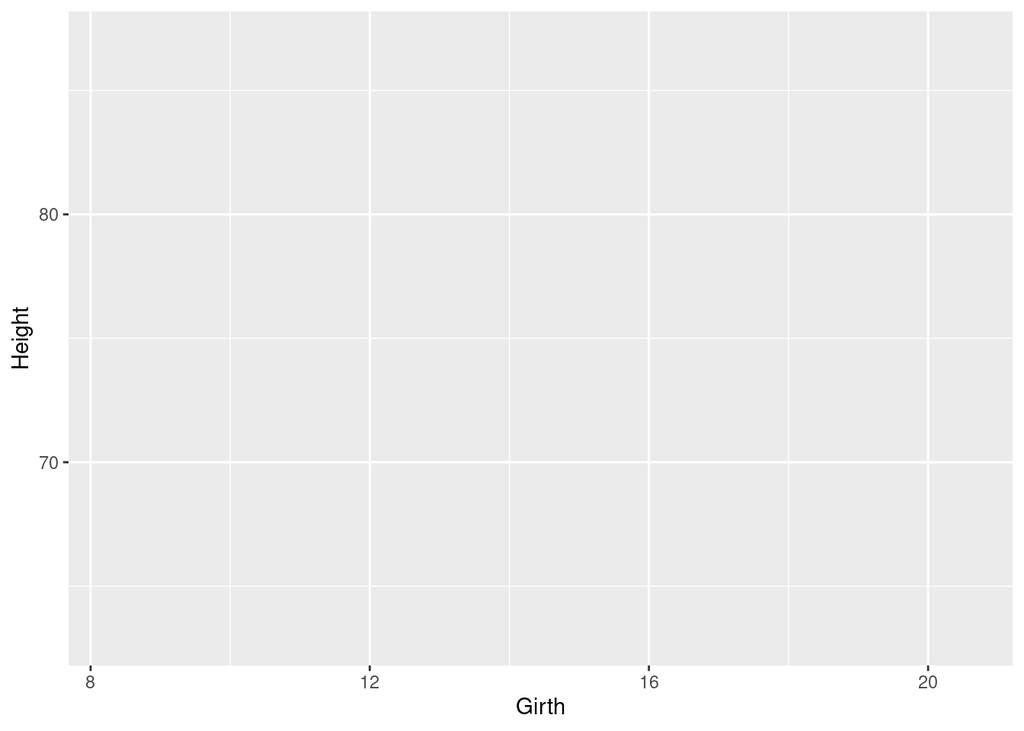

```r
trees %>%
  ggplot(aes(x = Girth, y = Height, size = Volume))
```

```r
trees %>%
  ggplot(aes(x = Girth, y = Height, size = Volume)) +
  geom_point()
```

[output not shown]

```r
ggplot() +
  geom_point(trees,
             aes(x = Girth, y = Height, size = Volume))
```

```
## Error: `mapping` must be created by `aes()`
```

```r
trees %>%
  ggplot(aes(x = Girth, y = Height)) +
  geom_point(aes(size = Volume))
```

[output not shown]

```r
trees %>%
  ggplot(aes(x = Girth, y = Height)) +
  geom_point(aes(size = Volume))
```

[output not shown]

```r
ggplot() +
  geom_point(data = trees,
             aes(x = Girth, y = Height, size = Volume))
```

[output not shown]

ans:2,3,4,5 (0.13/1 point)

ans:2,4,5 (0.25/1 point)

7. How can you create small multiples using `ggplot2`?
- Add multiple geoms to the plot using the + syntax
- Add facet_grid to the geom, specifying one or two columns to use for faceting
- Add a scales element to decrease the range of the plot scales
- Add facet_wrap to the geom, specifying the formula to use for faceting

ans:2,3 (0.50 / 1point)

ans:1,2,3 (0.25/1 point)

8. What does `geom_smooth(method = "lm")` do when it is added to a `ggplot` object?
- It adds a palette of colors for plotting the points in a scatterplot
- It adds transparency to the points to avoid over plotting
- It adds a nonlinear smoother to the plot
- **It adds a fitted linear regression line to the plot**
9. When plotting multiple panels using faceting for a single variable, what controls the order in which the panels are plotted?
- Panels are ordered by the number of data points in each panel
- **Panels are ordered by the alphabetical order or by the order of the levels of the faceting variable**
- Panels are ordered randomly
- The order of panels must be specified by the user
10. What function would you use to limit the range of the `x-axis` in a scatterplot?
- **`scale_x_continuous()`**
- `scale()`
- `geom_scale()`
- `scale_y_continuous()`

# 4 Conclusion

[figure not shown]

Awarded on `06 Aug 2021`

**Final Scores :** `85.26/100`

# 5 Appendix

## 5.1 Documenting File Creation

- File creation date: 2021-07-27
- File latest updated date: 2021-12-08
- R version 4.1.2 (2021-11-01)
- rmarkdown package version: 2.11
- File version: 0.2.1
- Author Profile: [®γσ, ξηg Lιαη Ημ](https://github.com/scibrokes/owner)
- GitHub: [Source Code](https://github.com/englianhu/Coursera-Mastering-Software-Development-in-R)
- Additional session information:

```r
suppressMessages(require('formattable', quietly = TRUE))
suppressMessages(require('knitr', quietly = TRUE))
suppressMessages(require('kableExtra', quietly = TRUE))

sys1 <- devtools::session_info()$platform |>
    unlist() |>
    {\(.) data.frame(row.names = 1:length(.),
                     Category = names(.), session_info = .)}()

sys2 <- data.frame(Sys.info()) |>
    {\(.) data.frame(Category = row.names(.), Sys.info = .[,1])}()

#remarks, dim(sys1), dim(sys2)
if (nrow(sys1) == 11 & nrow(sys2) == 8) {
  sys2 <- sys2 |>
    {\(.) rbind(., data.frame(
    Category = c('rmarkdown', 'rsconnect', 'Current time'),
    Sys.info = c(as.character(getwd()),
                 as.character(packageVersion('rsconnect')),
                 paste(as.character(lubridate::now('Asia/Tokyo')), 'JST 🌏'))))}()

} else if (nrow(sys1) == 10 & nrow(sys2) == 8) {
  sys1 %<>% rbind(., data.frame(Category = '', session_info = ''))

  sys2 <- sys2 |>
    {\(.) rbind(., data.frame(
    Category = c('rmarkdown', 'rsconnect', 'Current time'),
    Sys.info = c(as.character(getwd()),
                 as.character(packageVersion('rsconnect')),
                 paste(as.character(lubridate::now('Asia/Tokyo')), 'JST 🌏'))))}()
}

sys <- cbind(sys1, sys2) |>
  {\(.)
    kbl(., caption = 'Additional session information:')}() |>
  {\(.)
    kable_styling(., bootstrap_options = c('striped', 'hover', 'condensed', 'responsive'))}() |>
  {\(.)
    row_spec(., 0, background = 'DimGrey', color = 'yellow')}() |>
  {\(.)
    column_spec(., 1, background = 'CornflowerBlue', color = 'red')}() |>
  {\(.)
    column_spec(., 2, background = 'grey', color = 'black')}() |>
  {\(.)
    column_spec(., 3, background = 'CornflowerBlue', color = 'blue')}() |>
  {\(.)
    column_spec(., 4, background = 'grey', color = 'white')}() |>
  {\(.)
    row_spec(., 11, bold = TRUE, color = 'yellow', background = '#D7261E')}()

rm(sys1, sys2)
sys
```

Additional session information:

| Category | session_info | Category | Sys.info |
| --- | --- | --- | --- |
| version | R version 4.1.2 (2021-11-01) | sysname | Linux |
| os | Ubuntu 20.04.3 LTS | release | 5.4.0-1037-aws |
| system | x86_64, linux-gnu | version | #39~18.04.1-Ubuntu SMP Fri Jan 15 02:48:42 UTC 2021 |
| ui | X11 | nodename | application-3100168-deployment-10747036-p7mhs |
| language | (EN) | machine | x86_64 |
| collate | C.UTF-8 | login | unknown |
| ctype | C.UTF-8 | user | rstudio-user |
| tz | Asia/Tokyo | effective_user | rstudio-user |
| date | 2021-12-08 | rmarkdown | /cloud/project/04 Building Data Visualization Tools |
| pandoc | 2.14.0.3 @ /usr/lib/rstudio-server/bin/pandoc/ (via rmarkdown) | rsconnect | 0.8.25 |
|  |  | Current time | 2021-12-08 17:19:10 JST 🌏 |

## 5.2 Reference

1. [Mastering Software Development in R (web-base)](https://bookdown.org/rdpeng/RProgDA/). (or [Mastering Software Development in R.pdf](https://github.com/englianhu/Coursera-Mastering-Software-Development-in-R/blob/master/reference/Mastering%20Software%20Development%20in%20R.pdf))